# Additional analyses

As preregistered, below we report additional analyses for which we used the actual number of communicated words as DV.

# Set-up

## Packages

```r
library(brms)
library(ggplot2)
library(kableExtra)
library(lme4)
library(lmerTest)
library(rmarkdown)
library(performance)
library(see)
library(sjmisc)
library(tidyverse)

options(
  digits = 3
)
set.seed(170819)
```

## Custom functions

```r
# function to silence brms output
hush <-
  function(
    code
    ){
    sink("/dev/null")
    tmp = code
    sink()
    return(tmp)
    }
```

## Data

```r
d_words <- read_csv("data/DataAggregated_T1T2_nwords.csv")
d <- read_csv("data/data.csv")

# get words from dataframe
d$n_Words <- d_words$n_Words

# same as above; but original file name:
# d <- read_csv("data/DataAggregated_T1T2_costsbenefits.csv")

# load image for work in IDE
# load("data/image_words.RData")

d <- d |>
  rename(
    group = roles,
    gender = DE01_T1,
    age = DE02_01_T1,
    pol_stance = DE06_01_T1
  ) |>
  mutate(
    female = as.logical(2 - gender),
    gender = factor(gender, labels = c("female", "male")),
    n_Words = replace_na(n_Words, 0)
  )

# recode to make as sum coding
d$anonymity_dev <- factor(d$anonymity)
contrasts(d$anonymity_dev) <- contr.sum(2)
d$persistence_dev <- factor(d$persistence)
contrasts(d$persistence_dev) <- contr.sum(2)
```

# Descriptives

Let’s inspect distribution of words communicated.

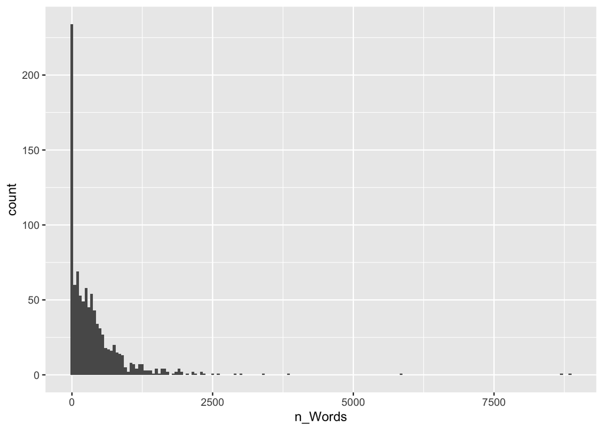

```r
ggplot(d, aes(n_Words)) +
  geom_histogram(binwidth = 50)
```

Looks like a zero-inflated poisson distribution. Confirms our preregistered approach to analyze data using zero-inflated Poisson approach.

```r
nrow(d[d$n_Words == 0, ]) / nrow(d)
```

```
[1] 0.206
```

Overall, 21% of participants without any written words.

We first look at the experimental group’s descriptives

```r
d |>
  group_by(persistence) |>
  summarize(n_Words_m = mean(n_Words)) |>
  as.data.frame() |>
  kable()
```

| persistence | n_Words_m |
| --- | --- |
| high | 365 |
| low | 422 |

Looking at persistence, we see there’s a slight difference among groups. Participants in the low persistence condition communicated more.

```r
d |>
  group_by(anonymity) |>
  summarize(n_Words_m = mean(n_Words)) |>
  as.data.frame() |>
  kable()
```

| anonymity | n_Words_m |
| --- | --- |
| high | 376 |
| low | 411 |

People who with *less* anonymity communicated *more*. But the difference isn’t particularly large.

```r
d |>
  group_by(persistence, anonymity) |>
  summarize(n_Words_m = mean(n_Words)) |>
  as.data.frame() |>
  kable()
```

| persistence | anonymity | n_Words_m |
| --- | --- | --- |
| high | high | 356 |
| high | low | 375 |
| low | high | 397 |
| low | low | 448 |

Looking at both groups combined, we see that low anonymity and low persistence created highest participation.

```r
d |>
  group_by(group) |>
  summarize(
    anonymity = anonymity[1],
    persistence = persistence[1],
    topic = topic[1],
    n_Words_m = mean(n_Words)
    ) |>
  rmarkdown::paged_table()
```

| group | anonymity | persistence | topic | n_Words_m |
| --- | --- | --- | --- | --- |
| Berlin1 | low | high | migration | 526 |
| Berlin2 | low | high | migration | 300 |
| Berlin3 | low | high | migration | 247 |
| Berlin4 | low | high | migration | 837 |
| Dubai1 | high | low | gender | 190 |
| Dubai2 | high | low | gender | 417 |
| Dubai3 | high | low | gender | 208 |
| Dubai4 | high | low | gender | 284 |
| Florenz1 | high | high | migration | 348 |
| Florenz2 | high | high | migration | 329 |

[output cut: 38 more lines]

Looking at the various individual groups, we do see some difference. Generally, this shows that communication varied across groups.

```r
d |>
  group_by(topic) |>
  summarize(n_Words_m = mean(n_Words)) |>
  as.data.frame() |>
  kable()
```

| topic | n_Words_m |
| --- | --- |
| climate | 388 |
| gender | 368 |
| migration | 426 |

Looking at topics specifically, we also see that there’s some variance.

# Bayesian mixed effects modeling

We analyze the data using Bayesian modelling.

## Fixed effects

We preregistered to analyze fixed effects.

```r
fit_fe_1 <-
  hush(
    brm(
      n_Words ~
        1 + persistence_dev * anonymity_dev + age + female + pol_stance +
        (1 | topic/group)
      , data = d
      , chains = 4
      , cores = 4
      , iter = 6000
      , warmup = 2000
      , family = zero_inflated_poisson()
      , control = list(
        adapt_delta = .95
        , max_treedepth = 12
        )
      , save_pars = save_pars(all = TRUE)
      , silent = 2
      )
  )
```

```
Warning: There were 552 divergent transitions after warmup. See
https://mc-stan.org/misc/warnings.html#divergent-transitions-after-warmup
to find out why this is a problem and how to eliminate them.
```

```
Warning: Examine the pairs() plot to diagnose sampling problems
```

Shows some convergence warnings. Let’s inspect model.

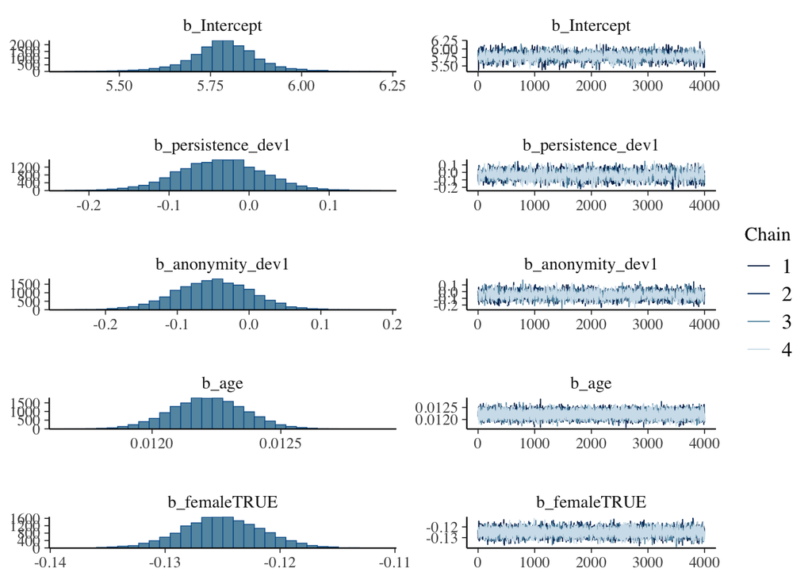

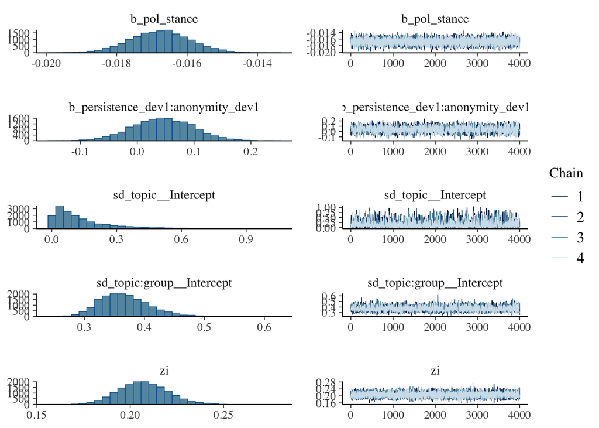

```r
plot(fit_fe_1, ask = FALSE)
```

Trace-plots look alright.

Let’s look at results.

```r
summary(fit_fe_1)
```

```
 Family: zero_inflated_poisson
  Links: mu = log; zi = identity
Formula: n_Words ~ 1 + persistence_dev * anonymity_dev + age + female + pol_stance + (1 | topic/group)
   Data: d (Number of observations: 960)
  Draws: 4 chains, each with iter = 6000; warmup = 2000; thin = 1;
         total post-warmup draws = 16000

Multilevel Hyperparameters:
~topic (Number of levels: 3)
              Estimate Est.Error l-95% CI u-95% CI Rhat Bulk_ESS Tail_ESS
sd(Intercept)     0.14      0.14     0.00     0.55 1.00     2554     4702

~topic:group (Number of levels: 48)
              Estimate Est.Error l-95% CI u-95% CI Rhat Bulk_ESS Tail_ESS
sd(Intercept)     0.37      0.04     0.30     0.46 1.00     2681     3482

Regression Coefficients:
                                Estimate Est.Error l-95% CI u-95% CI Rhat
Intercept                           5.79      0.10     5.58     5.98 1.00
persistence_dev1                   -0.04      0.05    -0.14     0.07 1.00
anonymity_dev1                     -0.05      0.05    -0.15     0.05 1.00
age                                 0.01      0.00     0.01     0.01 1.00
femaleTRUE                         -0.13      0.00    -0.13    -0.12 1.00
pol_stance                         -0.02      0.00    -0.02    -0.02 1.00
persistence_dev1:anonymity_dev1     0.04      0.05    -0.06     0.15 1.00
                                Bulk_ESS Tail_ESS
Intercept                           3333     4406
persistence_dev1                    2256     3030
anonymity_dev1                      2600     3825
age                                16666    12405
femaleTRUE                          7318     6447
pol_stance                         10557     7720
persistence_dev1:anonymity_dev1     2295     3497

Further Distributional Parameters:
   Estimate Est.Error l-95% CI u-95% CI Rhat Bulk_ESS Tail_ESS
zi     0.21      0.01     0.18     0.23 1.00     7006     5765

Draws were sampled using sampling(NUTS). For each parameter, Bulk_ESS
and Tail_ESS are effective sample size measures, and Rhat is the potential
scale reduction factor on split chains (at convergence, Rhat = 1).
```

No significant effect emerged.

Let’s inspect ICC

```r
var_ratio_fe <- performance::variance_decomposition(
  fit_fe_1
  , by_group = TRUE)
var_ratio_fe
```

```
# Random Effect Variances and ICC

Conditioned on: all random effects

## Variance Ratio (comparable to ICC)
Ratio: 0.45  CI 95%: [0.17 0.64]

## Variances of Posterior Predicted Distribution
Conditioned on fixed effects: 43714.80  CI 95%: [28546.64 65961.20]
Conditioned on rand. effects: 79727.93  CI 95%: [74247.18 85107.51]

## Difference in Variances
Difference: 35884.99  CI 95%: [13659.26 51447.57]
```

45.103 percent of variance in words communicated explained by both topics and groups.

Let’s visualize results to see what they exactly mean.

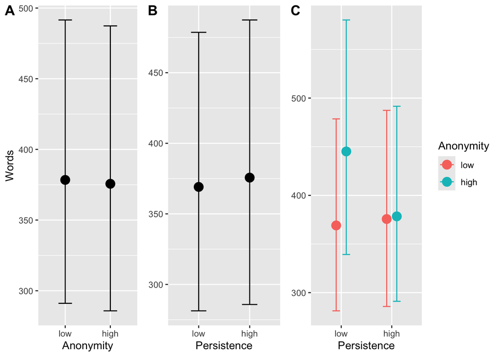

```r
p <- plot(
  conditional_effects(
    fit_fe_1
    ),
  ask = FALSE,
  plot = FALSE
  )

p_anon <-
  p[["anonymity_dev"]] +
  xlab("Anonymity") +
  ylab("Words") +
  scale_x_discrete(
    limits = rev
  )
  #    ) +
  # scale_y_continuous(
  #   limits = c(5, 14)
  #   , breaks = c(6, 8, 10, 12, 14)
  #   )

p_pers <-
  p[["persistence_dev"]] +
  xlab("Persistence") +
  ylab("Words") +
  scale_x_discrete(
    limits = rev
   ) +
  # scale_y_continuous(
  #   limits = c(5, 14)
  #   , breaks = c(6, 8, 10, 12, 14)
  #   ) +
  theme(
    axis.title.y = element_blank()
    )

p_int <-
  p[["persistence_dev:anonymity_dev"]] +
  xlab("Persistence") +
  scale_x_discrete(
    limits = rev
     ) +
  scale_color_discrete(
    labels = c("low", "high")
    ) +
  guides(
    fill = "none",
    color = guide_legend(
      title = "Anonymity"
      )
    ) +
  # scale_y_continuous(
  #   limits = c(5, 14)
  #   , breaks = c(6, 8, 10, 12, 14)
  #   ) +
  theme(
    axis.title.y = element_blank()
    )

plot <- cowplot::plot_grid(
  p_anon, p_pers, p_int,
  labels = c('A', 'B', "C"),
  nrow = 1,
  rel_widths = c(2, 2, 3)
  )

plot
```

```r
ggsave("figures/results.png", plot, width = 8, height = 4)
```

Let’s look at posteriors

```r
p_1 <-
  pp_check(fit_fe_1) +
  labs(title = "Zero-inflated poisson")
```

```
Using 10 posterior draws for ppc type 'dens_overlay' by default.
```

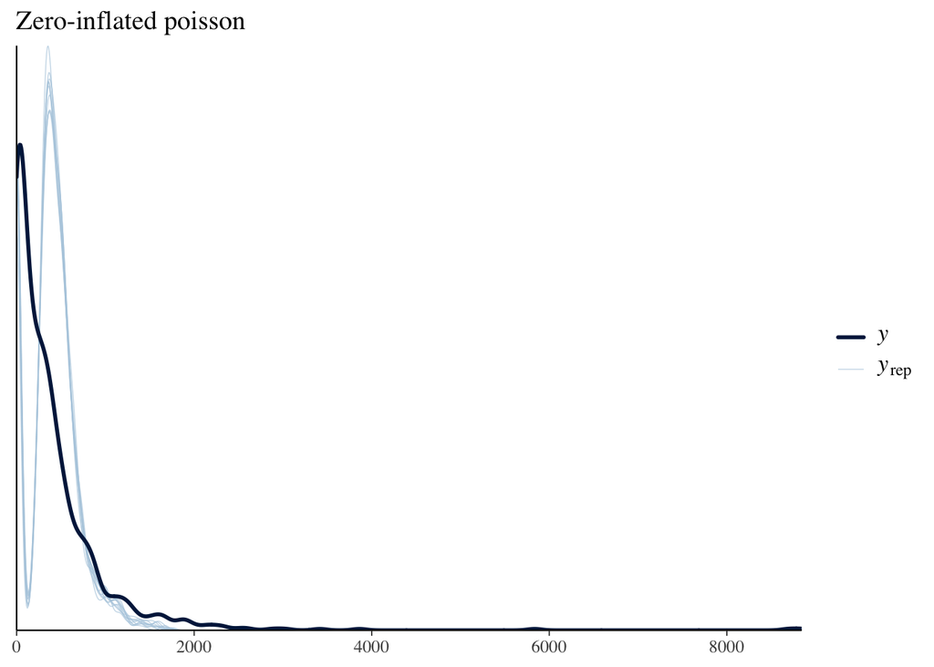

```r
p_1
```

The actual distribution cannot be precisely reproduced, but it’s also not too far off.

## Random effects

We preregistered to explore and compare models with random effects. So let’s model how the experimental conditions affect the outcomes differently depending on topic.

```r
fit_re_1 <-
  hush(
    brm(
      n_Words ~
        1 + persistence_dev * anonymity_dev + age + female + pol_stance +
        (1 + persistence_dev * anonymity_dev | topic) +
        (1 | topic:group)
      , data = d
      , chains = 4
      , cores = 4
      , iter = 6000
      , warmup = 2000
      , family = zero_inflated_poisson()
      , control = list(
        adapt_delta = .95
        , max_treedepth = 15
        )
      , save_pars = save_pars(all = TRUE)
    )
  )
```

```
Warning: There were 1395 divergent transitions after warmup. See
https://mc-stan.org/misc/warnings.html#divergent-transitions-after-warmup
to find out why this is a problem and how to eliminate them.
```

```
Warning: Examine the pairs() plot to diagnose sampling problems
```

Shows some convergence warnings.

Let’s inspect model.

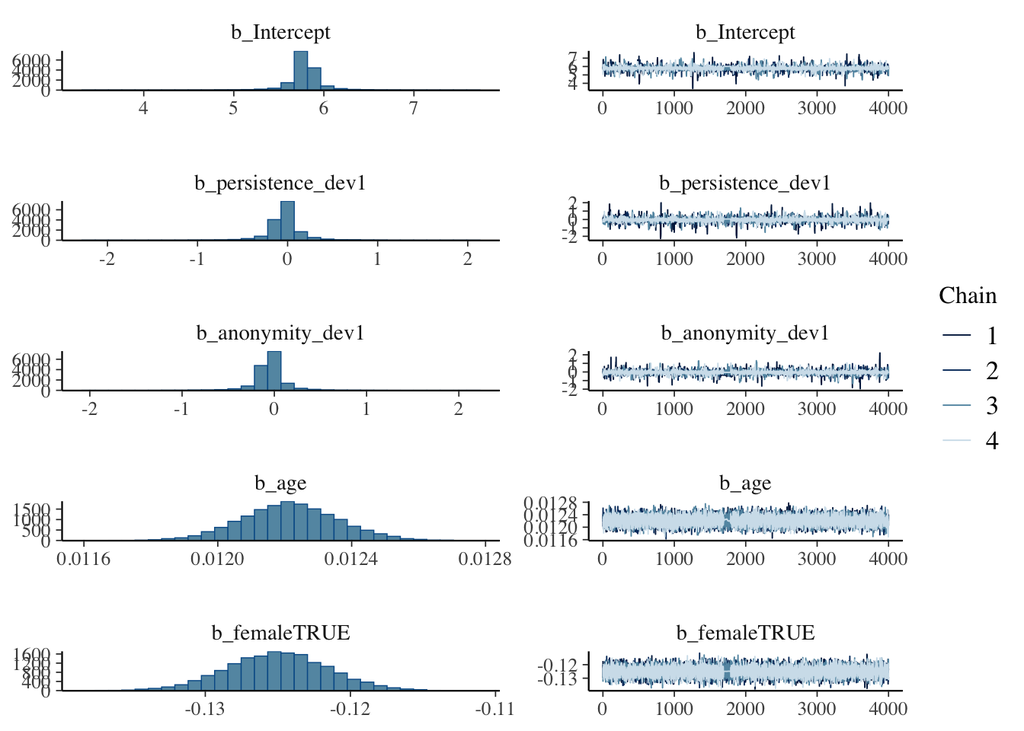

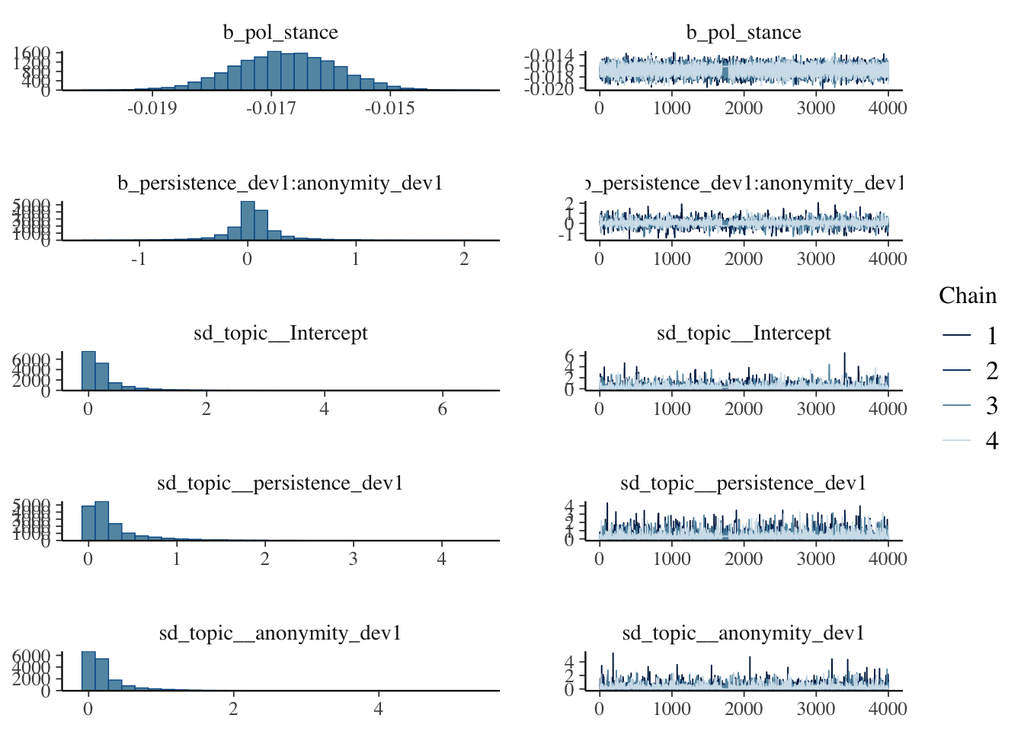

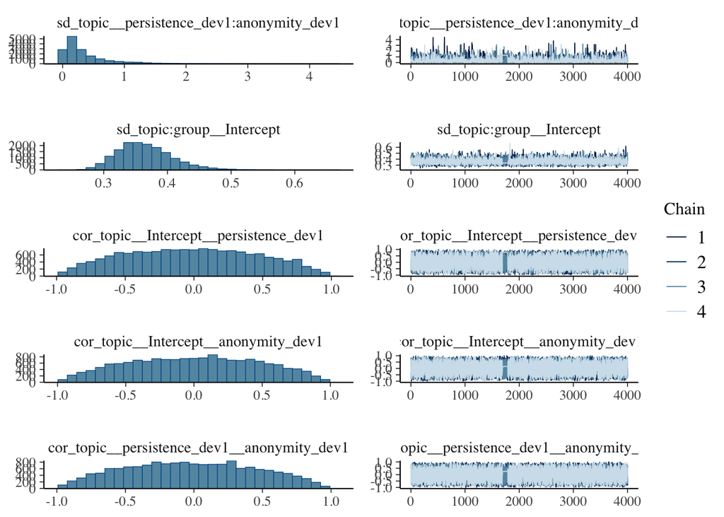

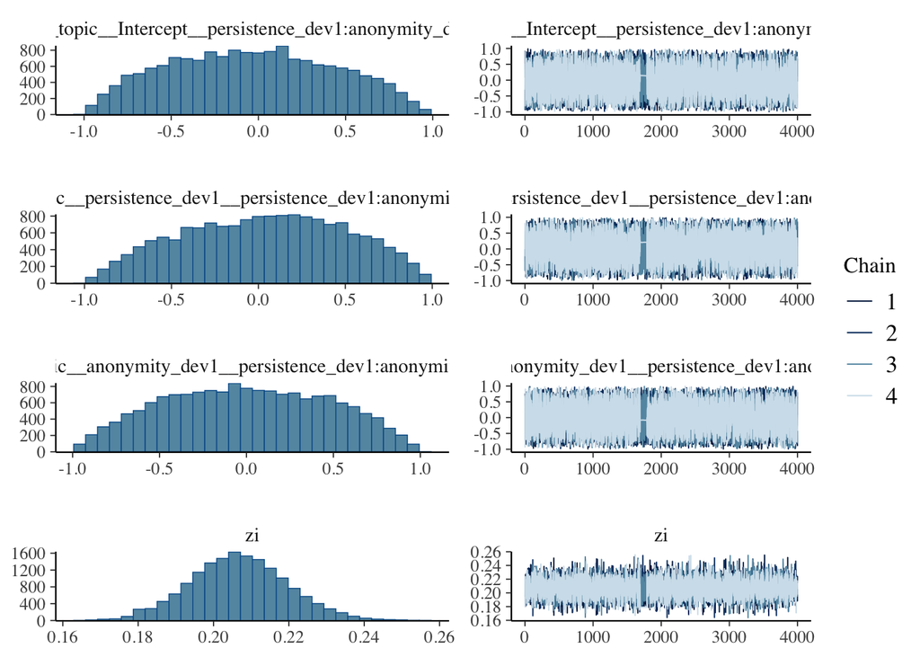

```r
plot(fit_re_1, ask = FALSE)
```

Traceplots look alright.

Let’s look at results.

```r
summary(fit_re_1)
```

```
 Family: zero_inflated_poisson
  Links: mu = log; zi = identity
Formula: n_Words ~ 1 + persistence_dev * anonymity_dev + age + female + pol_stance + (1 + persistence_dev * anonymity_dev | topic) + (1 | topic:group)
   Data: d (Number of observations: 960)
  Draws: 4 chains, each with iter = 6000; warmup = 2000; thin = 1;
         total post-warmup draws = 16000

Multilevel Hyperparameters:
~topic (Number of levels: 3)
                                                      Estimate Est.Error
sd(Intercept)                                             0.25      0.36
sd(persistence_dev1)                                      0.27      0.37
sd(anonymity_dev1)                                        0.23      0.33
sd(persistence_dev1:anonymity_dev1)                       0.35      0.40
cor(Intercept,persistence_dev1)                          -0.02      0.47
cor(Intercept,anonymity_dev1)                             0.00      0.47
cor(persistence_dev1,anonymity_dev1)                     -0.02      0.46
cor(Intercept,persistence_dev1:anonymity_dev1)           -0.03      0.46
cor(persistence_dev1,persistence_dev1:anonymity_dev1)     0.04      0.46
cor(anonymity_dev1,persistence_dev1:anonymity_dev1)       0.00      0.46
                                                      l-95% CI u-95% CI Rhat
sd(Intercept)                                             0.00     1.30 1.00
sd(persistence_dev1)                                      0.01     1.34 1.00
sd(anonymity_dev1)                                        0.00     1.19 1.00
sd(persistence_dev1:anonymity_dev1)                       0.01     1.45 1.00
cor(Intercept,persistence_dev1)                          -0.84     0.83 1.00
cor(Intercept,anonymity_dev1)                            -0.84     0.84 1.00
cor(persistence_dev1,anonymity_dev1)                     -0.84     0.82 1.00
cor(Intercept,persistence_dev1:anonymity_dev1)           -0.85     0.81 1.00
cor(persistence_dev1,persistence_dev1:anonymity_dev1)    -0.81     0.84 1.00
cor(anonymity_dev1,persistence_dev1:anonymity_dev1)      -0.83     0.83 1.00
                                                      Bulk_ESS Tail_ESS
sd(Intercept)                                             5391     6904
sd(persistence_dev1)                                      4888     6903
sd(anonymity_dev1)                                        4200     5188
sd(persistence_dev1:anonymity_dev1)                       3355     1209
cor(Intercept,persistence_dev1)                           9806     1289
cor(Intercept,anonymity_dev1)                            17529    11188
cor(persistence_dev1,anonymity_dev1)                     13950    12413
cor(Intercept,persistence_dev1:anonymity_dev1)           15722    12168
```

[output cut: 17 more lines]

```
Intercept                           6315     5760
persistence_dev1                    7361     5679
anonymity_dev1                      7196     5404
age                                15409    14365
femaleTRUE                         21841    10097
pol_stance                         16190     9405
persistence_dev1:anonymity_dev1     5160     5346

Further Distributional Parameters:
   Estimate Est.Error l-95% CI u-95% CI Rhat Bulk_ESS Tail_ESS
zi     0.21      0.01     0.18     0.23 1.00     5349     1072

Draws were sampled using sampling(NUTS). For each parameter, Bulk_ESS
and Tail_ESS are effective sample size measures, and Rhat is the potential
scale reduction factor on split chains (at convergence, Rhat = 1).
```

Again, no main or interaction effects.

## Hurdle

Let’s now estimate a fixed effects model with hurdles.

```r
fit_hrdl_1 <-
  hush(
    brm(
      bf(
        n_Words ~
          1 + persistence_dev * anonymity_dev + age + female + pol_stance +
          (1 | topic) +
          (1 | topic:group),
        zi ~
          1 + persistence_dev * anonymity_dev + age + female + pol_stance +
          (1 | topic) +
          (1 | topic:group)
      )
    , data = d
    , chains = 4
    , cores = 4
    , iter = 6000
    , warmup = 2000
    , family = zero_inflated_poisson()
    , control = list(
      adapt_delta = .95
      , max_treedepth = 15
      )
    )
  )
```

```
Warning: Examine the pairs() plot to diagnose sampling problems
```

```
Warning: The largest R-hat is 1.6, indicating chains have not mixed.
Running the chains for more iterations may help. See
https://mc-stan.org/misc/warnings.html#r-hat
```

```
Warning: Bulk Effective Samples Size (ESS) is too low, indicating posterior means and medians may be unreliable.
Running the chains for more iterations may help. See
https://mc-stan.org/misc/warnings.html#bulk-ess
```

```
Warning: Tail Effective Samples Size (ESS) is too low, indicating posterior variances and tail quantiles may be unreliable.
Running the chains for more iterations may help. See
https://mc-stan.org/misc/warnings.html#tail-ess
```

Agian, some warnings.

Let’s inspect model.

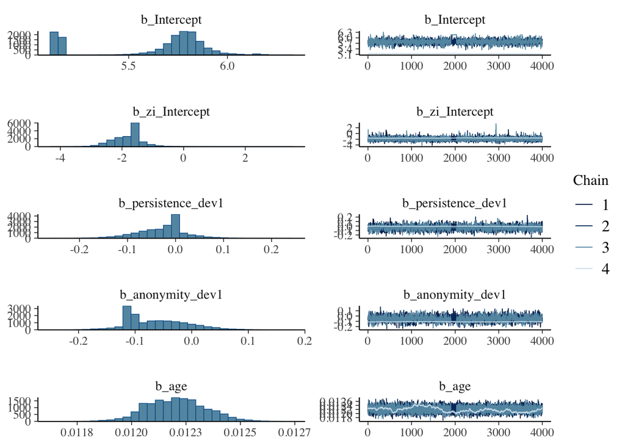

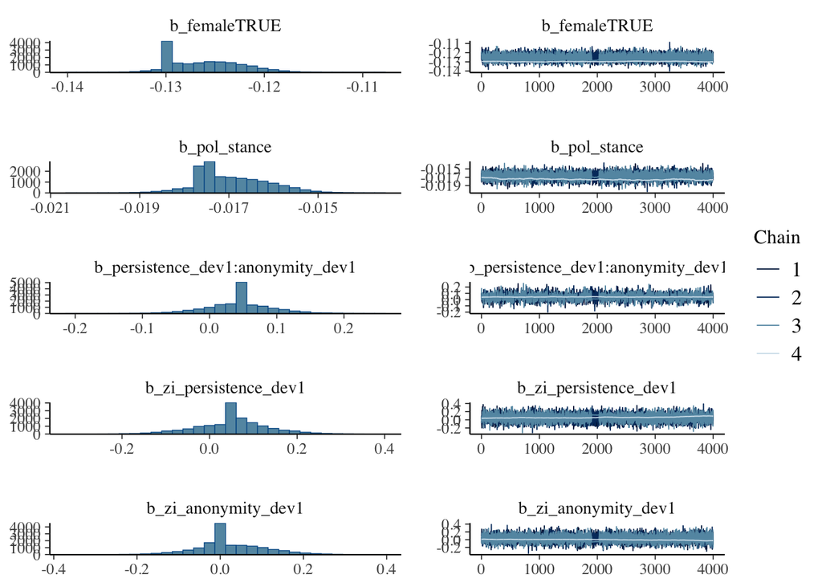

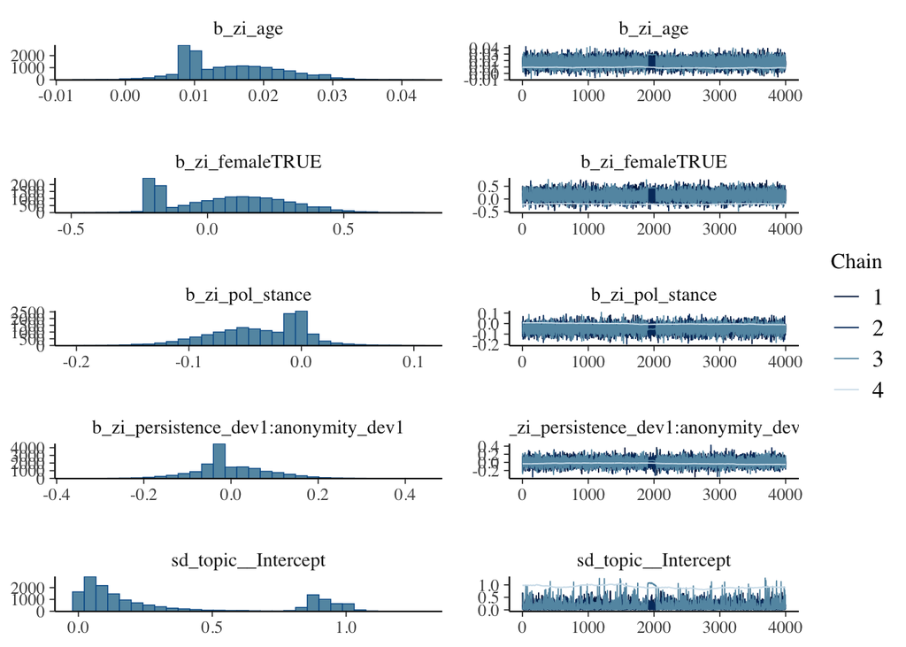

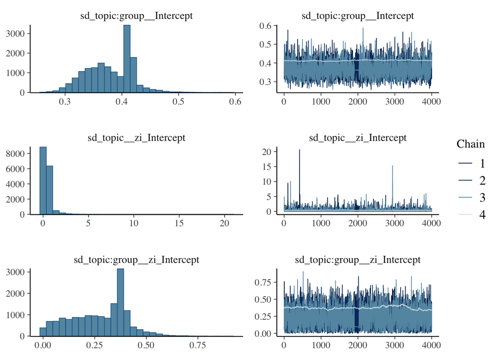

```r
plot(fit_hrdl_1, ask = FALSE)
```

```r
summary(fit_hrdl_1)
```

```
 Family: zero_inflated_poisson
  Links: mu = log; zi = logit
Formula: n_Words ~ 1 + persistence_dev * anonymity_dev + age + female + pol_stance + (1 | topic) + (1 | topic:group)
         zi ~ 1 + persistence_dev * anonymity_dev + age + female + pol_stance + (1 | topic) + (1 | topic:group)
   Data: d (Number of observations: 960)
  Draws: 4 chains, each with iter = 6000; warmup = 2000; thin = 1;
         total post-warmup draws = 16000

Multilevel Hyperparameters:
~topic (Number of levels: 3)
                 Estimate Est.Error l-95% CI u-95% CI Rhat Bulk_ESS Tail_ESS
sd(Intercept)        0.34      0.37     0.01     1.01 1.47        8       30
sd(zi_Intercept)     0.37      0.49     0.01     1.55 1.09       51     3081

~topic:group (Number of levels: 48)
                 Estimate Est.Error l-95% CI u-95% CI Rhat Bulk_ESS Tail_ESS
sd(Intercept)        0.38      0.04     0.30     0.45 1.15       18     2374
sd(zi_Intercept)     0.27      0.14     0.02     0.51 1.10       27     3529

Regression Coefficients:
                                   Estimate Est.Error l-95% CI u-95% CI Rhat
Intercept                              5.63      0.29     5.13     6.00 1.57
zi_Intercept                          -1.80      0.48    -2.77    -0.89 1.17
persistence_dev1                      -0.03      0.05    -0.13     0.06 1.20
anonymity_dev1                        -0.06      0.05    -0.15     0.05 1.15
age                                    0.01      0.00     0.01     0.01 1.04
femaleTRUE                            -0.13      0.00    -0.13    -0.12 1.20
pol_stance                            -0.02      0.00    -0.02    -0.02 1.10
persistence_dev1:anonymity_dev1        0.04      0.05    -0.05     0.14 1.45
zi_persistence_dev1                    0.05      0.08    -0.12     0.22 1.26
zi_anonymity_dev1                      0.02      0.08    -0.14     0.20 1.38
zi_age                                 0.02      0.01     0.00     0.03 1.16
zi_femaleTRUE                          0.06      0.21    -0.22     0.47 1.37
zi_pol_stance                         -0.04      0.04    -0.12     0.03 1.15
zi_persistence_dev1:anonymity_dev1    -0.00      0.08    -0.16     0.17 1.31
                                   Bulk_ESS Tail_ESS
Intercept                                 7       13
zi_Intercept                             46     2461
persistence_dev1                        115     3180
anonymity_dev1                           19     1741
age                                     121     5475
femaleTRUE                               13     1324
pol_stance                               25     4709
persistence_dev1:anonymity_dev1        2329     3366
zi_persistence_dev1                     405      574
zi_anonymity_dev1                       115      884
zi_age                                   16      479
zi_femaleTRUE                             9       75
zi_pol_stance                            17     2796
zi_persistence_dev1:anonymity_dev1       88      827

Draws were sampled using sampling(NUTS). For each parameter, Bulk_ESS
and Tail_ESS are effective sample size measures, and Rhat is the potential
scale reduction factor on split chains (at convergence, Rhat = 1).
```

# Exploratory Analyses

## Frequentist

Look at results from a frequentist perspective.

### Fixed effects

Estimate nested model.

```r
fit_fe_1_frq <-
  lmer(
    n_Words ~
      1 +
      (1 | topic/group) +
      persistence_dev * anonymity_dev + age + female + pol_stance
    , data = d
    )

summary(fit_fe_1_frq)
```

```
Linear mixed model fit by REML. t-tests use Satterthwaite's method [
lmerModLmerTest]
Formula: n_Words ~ 1 + (1 | topic/group) + persistence_dev * anonymity_dev +
    age + female + pol_stance
   Data: d

REML criterion at convergence: 15030

Scaled residuals:
   Min     1Q Median     3Q    Max
-1.208 -0.507 -0.235  0.221 13.409

Random effects:
 Groups      Name        Variance Std.Dev.
 group:topic (Intercept)  13591   117
 topic       (Intercept)      0     0
 Residual                381808   618
Number of obs: 960, groups:  group:topic, 48; topic, 3

Fixed effects:
                                Estimate Std. Error      df t value Pr(>|t|)
(Intercept)                      277.629    104.780 910.923    2.65   0.0082 **
persistence_dev1                 -28.500     26.099  43.505   -1.09   0.2808
anonymity_dev1                   -24.313     26.260  44.563   -0.93   0.3595
age                                3.663      1.760 950.062    2.08   0.0377 *
femaleTRUE                       -60.301     43.364 946.729   -1.39   0.1647
pol_stance                         0.468     10.152 949.443    0.05   0.9632
persistence_dev1:anonymity_dev1    6.706     26.168  43.950    0.26   0.7990
---
Signif. codes:  0 '***' 0.001 '**' 0.01 '*' 0.05 '.' 0.1 ' ' 1

Correlation of Fixed Effects:
            (Intr) prss_1 anny_1 age    fmTRUE pl_stn
prsstnc_dv1  0.018
annymty_dv1  0.063  0.000
age         -0.758 -0.011 -0.058
femaleTRUE  -0.468 -0.016  0.049  0.251
pol_stance  -0.546 -0.011 -0.067 -0.002  0.063
prsstn_1:_1  0.023  0.001 -0.002 -0.053 -0.039  0.045
optimizer (nloptwrap) convergence code: 0 (OK)
boundary (singular) fit: see help('isSingular')
```

Quite weird that topic doesn’t get any variance at all. Perhaps due to small cluster size? With Bayesian estimation, it worked alright. Also, again no significant effects.

Estimate without nesting.

```r
fit_fe_2_frq <-
  lmer(
    n_Words ~
      1 +
      (1 | group) +
      persistence_dev * anonymity_dev + age + female + pol_stance + topic
    , data = d
    )

summary(fit_fe_2_frq)
```

```
Linear mixed model fit by REML. t-tests use Satterthwaite's method [
lmerModLmerTest]
Formula: n_Words ~ 1 + (1 | group) + persistence_dev * anonymity_dev +
    age + female + pol_stance + topic
   Data: d

REML criterion at convergence: 15009

Scaled residuals:
   Min     1Q Median     3Q    Max
-1.200 -0.508 -0.233  0.219 13.366

Random effects:
 Groups   Name        Variance Std.Dev.
 group    (Intercept)  14508   120
 Residual             381804   618
Number of obs: 960, groups:  group, 48

Fixed effects:
                                Estimate Std. Error      df t value Pr(>|t|)
(Intercept)                      267.434    111.482 618.730    2.40    0.017 *
persistence_dev1                 -28.506     26.462  41.531   -1.08    0.288
anonymity_dev1                   -24.265     26.622  42.515   -0.91    0.367
age                                3.680      1.762 948.098    2.09    0.037 *
femaleTRUE                       -59.385     43.404 944.642   -1.37    0.172
pol_stance                         0.324     10.160 947.596    0.03    0.975
topicgender                      -13.401     64.870  41.660   -0.21    0.837
topicmigration                    42.524     64.842  41.590    0.66    0.516
persistence_dev1:anonymity_dev1    6.660     26.531  41.946    0.25    0.803
---
Signif. codes:  0 '***' 0.001 '**' 0.01 '*' 0.05 '.' 0.1 ' ' 1

Correlation of Fixed Effects:
            (Intr) prss_1 anny_1 age    fmTRUE pl_stn tpcgnd tpcmgr
prsstnc_dv1  0.016
annymty_dv1  0.059  0.000
age         -0.722 -0.011 -0.057
femaleTRUE  -0.435 -0.016  0.048  0.250
pol_stance  -0.505 -0.010 -0.066 -0.003  0.064
topicgender -0.285  0.000 -0.002  0.020 -0.028 -0.024
topicmigrtn -0.300  0.000 -0.001  0.028  0.000 -0.018  0.500
prsstn_1:_1  0.022  0.001 -0.002 -0.052 -0.039  0.044 -0.001 -0.002
```

Also shows no significant effects.

For curiosity, estimate also without hierarchical structure.

```r
fit_fe_3_frq <-
  lm(
    n_Words ~
      1 +
      persistence_dev * anonymity_dev + topic + age + female + pol_stance
    , data = d
    )

summary(fit_fe_3_frq)
```

```
Call:
lm(formula = n_Words ~ 1 + persistence_dev * anonymity_dev +
    topic + age + female + pol_stance, data = d)

Residuals:
   Min     1Q Median     3Q    Max
  -604   -327   -150    125   8448

Coefficients:
                                Estimate Std. Error t value Pr(>|t|)
(Intercept)                       239.86     108.03    2.22    0.027 *
persistence_dev1                  -28.61      20.28   -1.41    0.159
anonymity_dev1                    -25.20      20.49   -1.23    0.219
topicgender                       -13.59      49.74   -0.27    0.785
topicmigration                     42.39      49.71    0.85    0.394
age                                 3.91       1.77    2.21    0.027 *
femaleTRUE                        -60.28      43.67   -1.38    0.168
pol_stance                          3.77      10.21    0.37    0.712
persistence_dev1:anonymity_dev1     6.94      20.37    0.34    0.733
---
Signif. codes:  0 '***' 0.001 '**' 0.01 '*' 0.05 '.' 0.1 ' ' 1

Residual standard error: 628 on 951 degrees of freedom
Multiple R-squared:  0.0139,    Adjusted R-squared:  0.00557
F-statistic: 1.67 on 8 and 951 DF,  p-value: 0.101
```

Also here, no significant effects.

## Gender

As preregistered, let’s see if effects differ across genders.

```r
fit_fe_gen <-
  hush(
    brm(
      n_Words ~
        1 + persistence_dev * anonymity_dev * gender + age + pol_stance +
        (1 | topic/group)
      , data = d
      , chains = 4
      , cores = 4
      , iter = 8000
      , warmup = 2000
      , family = zero_inflated_poisson()
      , control = list(
        adapt_delta = .95
        , max_treedepth = 12
        )
      )
  )
```

```
Warning: There were 668 divergent transitions after warmup. See
https://mc-stan.org/misc/warnings.html#divergent-transitions-after-warmup
to find out why this is a problem and how to eliminate them.
```

```
Warning: There were 1932 transitions after warmup that exceeded the maximum treedepth. Increase max_treedepth above 12. See
https://mc-stan.org/misc/warnings.html#maximum-treedepth-exceeded
```

```
Warning: Examine the pairs() plot to diagnose sampling problems
```

Again, some warnings.

Let’s inspect model.

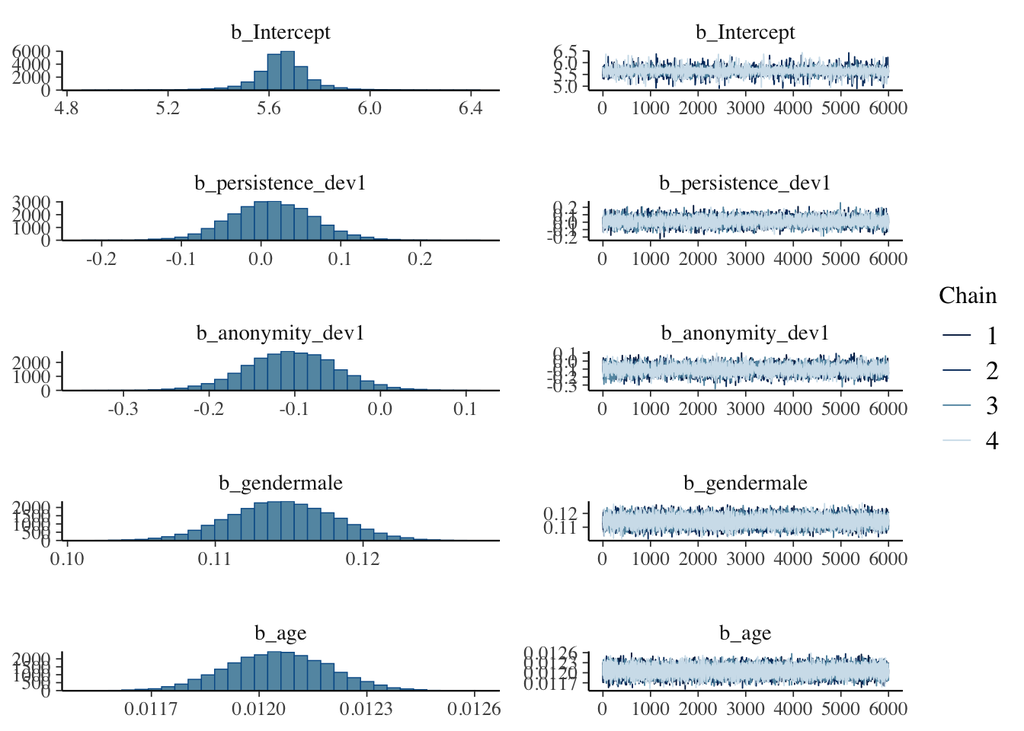

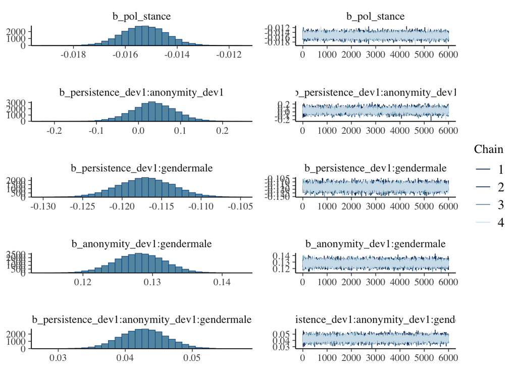

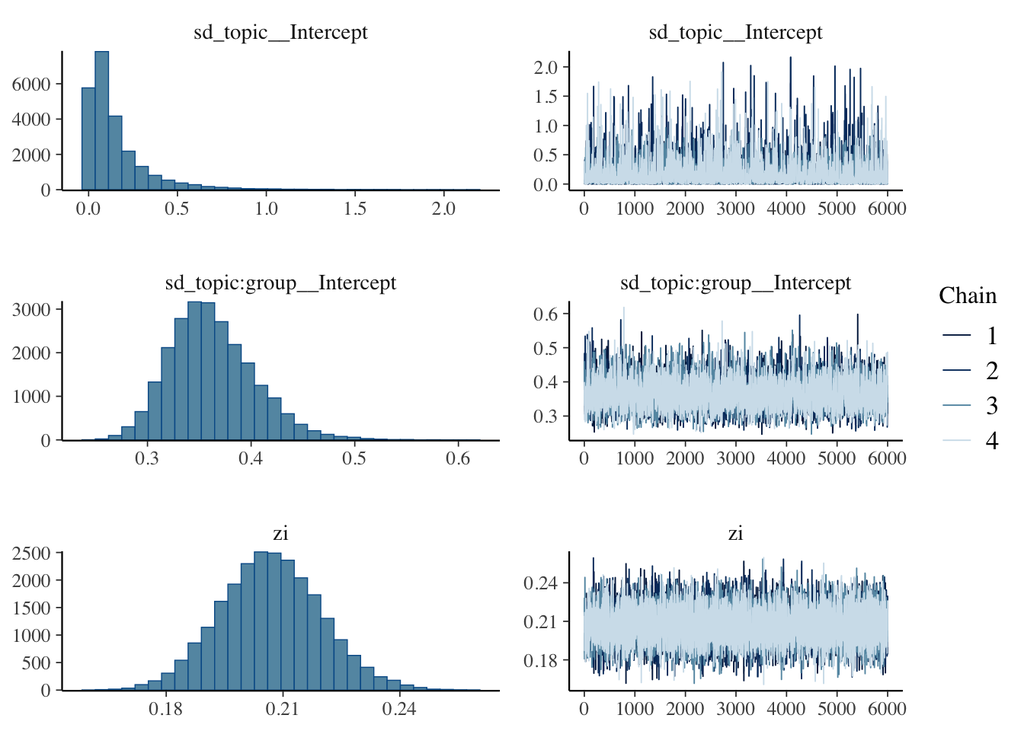

```r
plot(fit_fe_gen, ask = FALSE)
```

Traceplots look alright.

Let’s look at results.

```r
summary(fit_fe_gen)
```

```
 Family: zero_inflated_poisson
  Links: mu = log; zi = identity
Formula: n_Words ~ 1 + persistence_dev * anonymity_dev * gender + age + pol_stance + (1 | topic/group)
   Data: d (Number of observations: 960)
  Draws: 4 chains, each with iter = 8000; warmup = 2000; thin = 1;
         total post-warmup draws = 24000

Multilevel Hyperparameters:
~topic (Number of levels: 3)
              Estimate Est.Error l-95% CI u-95% CI Rhat Bulk_ESS Tail_ESS
sd(Intercept)     0.16      0.20     0.00     0.68 1.00     4328     5277

~topic:group (Number of levels: 48)
              Estimate Est.Error l-95% CI u-95% CI Rhat Bulk_ESS Tail_ESS
sd(Intercept)     0.36      0.04     0.29     0.45 1.00     5814     7818

Regression Coefficients:
                                           Estimate Est.Error l-95% CI u-95% CI
Intercept                                      5.65      0.12     5.39     5.89
persistence_dev1                               0.01      0.05    -0.09     0.12
anonymity_dev1                                -0.10      0.05    -0.21     0.00
gendermale                                     0.11      0.00     0.11     0.12
age                                            0.01      0.00     0.01     0.01
pol_stance                                    -0.02      0.00    -0.02    -0.01
persistence_dev1:anonymity_dev1                0.04      0.05    -0.07     0.14
persistence_dev1:gendermale                   -0.12      0.00    -0.12    -0.11
anonymity_dev1:gendermale                      0.13      0.00     0.12     0.13
persistence_dev1:anonymity_dev1:gendermale     0.04      0.00     0.04     0.05
                                           Rhat Bulk_ESS Tail_ESS
Intercept                                  1.00     8096     6617
persistence_dev1                           1.00     7001     8930
anonymity_dev1                             1.00     6682     6900
gendermale                                 1.00    17172    12719
age                                        1.00    24748    19520
pol_stance                                 1.00    20680    13875
persistence_dev1:anonymity_dev1            1.00     6765     8163
persistence_dev1:gendermale                1.00    19135    12599
anonymity_dev1:gendermale                  1.00    19549    13771
persistence_dev1:anonymity_dev1:gendermale 1.00    18969    13261

Further Distributional Parameters:
   Estimate Est.Error l-95% CI u-95% CI Rhat Bulk_ESS Tail_ESS
zi     0.21      0.01     0.18     0.23 1.00    18269    12552

Draws were sampled using sampling(NUTS). For each parameter, Bulk_ESS
and Tail_ESS are effective sample size measures, and Rhat is the potential
scale reduction factor on split chains (at convergence, Rhat = 1).
```

Indeed, several gender effects.

- For females, the effect of persistence is larger, that is more positive.
- For females, the effect of anonymity is smaller, that is more negative.
- For females, the interaction effect is also a bit smaller, that is more negative.

Let’s visualize results.

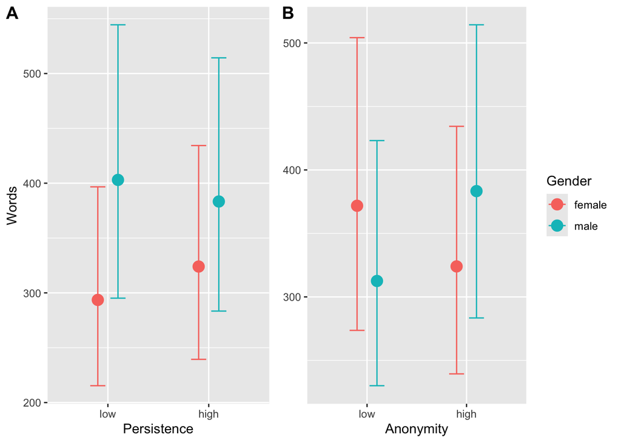

```r
p_gen <- plot(
  conditional_effects(
    fit_fe_gen
    ),
  ask = FALSE,
  plot = FALSE
  )

p_gen_pers <-
  p_gen[["persistence_dev:gender"]] +
  xlab("Persistence") +
  ylab("Words") +
  # scale_y_continuous(
  #   limits = c(4, 15),
  #   breaks = c(5, 7.5, 10, 12.5, 15)
  # ) +
  scale_x_discrete(
    limits = rev
  ) +
  guides(
    fill = "none"
    , color = "none"
    )

p_gen_anon <-
  p_gen[["anonymity_dev:gender"]] +
  xlab("Anonymity") +
  ylab("Words") +
  # scale_y_continuous(
  #   limits = c(3.5, 15),
  #   breaks = c(5, 7.5, 10, 12.5, 15)
  # ) +
  theme(
    axis.title.y = element_blank()
    ) +
  guides(
    fill = "none"
    ) +
  scale_x_discrete(
    limits = rev
  ) +
  scale_color_discrete(
    name = "Gender"
    )

plot_gen <- cowplot::plot_grid(
  p_gen_pers, p_gen_anon,
  labels = c('A', 'B'),
  nrow = 1,
  rel_widths = c(4, 5)
  )

plot_gen
```

```r
ggsave("figures/results_gen.png", plot_gen, width = 8, height = 4)
```

## Benefits

Let’s see if benefits differ across experimental groups.

We first look at the experimental group’s descriptives

```r
d |>
  group_by(persistence) |>
  summarize(benefits_m = mean(benefits, na.rm = TRUE)) |>
  as.data.frame() |>
  kable()
```

| persistence | benefits_m |
| --- | --- |
| high | 3.12 |
| low | 3.23 |

Looking at persistence, we see people with lower persistence reporting slightly higher benefits.

```r
d |>
  group_by(anonymity) |>
  summarize(benefits_m = mean(benefits, na.rm = TRUE)) |>
  as.data.frame() |>
  kable()
```

| anonymity | benefits_m |
| --- | --- |
| high | 3.15 |
| low | 3.20 |

Looking at anonymity, we see people with low anonymity reporting marginally higher benefits.

```r
d |>
  group_by(persistence, anonymity) |>
  summarize(benefits_m = mean(benefits, na.rm = T)) |>
  as.data.frame() |>
  kable()
```

| persistence | anonymity | benefits_m |
| --- | --- | --- |
| high | high | 3.07 |
| high | low | 3.18 |
| low | high | 3.22 |
| low | low | 3.23 |

Looking at both groups combined, we see that low anonymity and low persistence yielded highest benefits.

Let’s look if effects are significant.

```r
fit_fe_ben_1 <-
  hush(
    brm(
      benefits ~
        1 + persistence_dev * anonymity_dev  + age + female + pol_stance +
        (1 | topic/group)
      , data = d
      , chains = 4
      , cores = 4
      , iter = 6000
      , warmup = 2000
      , control = list(
        adapt_delta = .95
        , max_treedepth = 12
        )
      )
  )
```

Let’s inspect model.

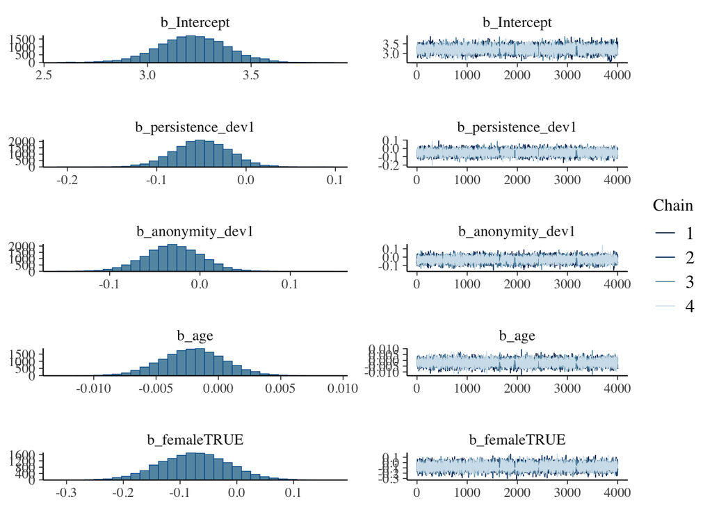

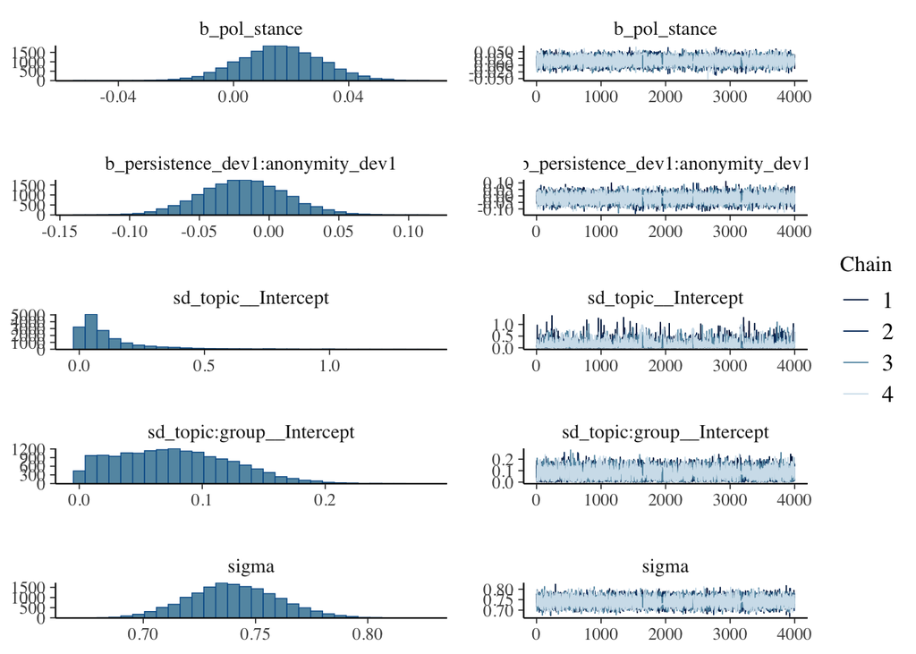

```r
plot(fit_fe_ben_1, ask = FALSE)
```

Traceplots look alright.

Let’s look at results.

```r
summary(fit_fe_ben_1)
```

```
 Family: gaussian
  Links: mu = identity; sigma = identity
Formula: benefits ~ 1 + persistence_dev * anonymity_dev + age + female + pol_stance + (1 | topic/group)
   Data: d (Number of observations: 705)
  Draws: 4 chains, each with iter = 6000; warmup = 2000; thin = 1;
         total post-warmup draws = 16000

Multilevel Hyperparameters:
~topic (Number of levels: 3)
              Estimate Est.Error l-95% CI u-95% CI Rhat Bulk_ESS Tail_ESS
sd(Intercept)     0.12      0.15     0.00     0.57 1.00     2529     1623

~topic:group (Number of levels: 48)
              Estimate Est.Error l-95% CI u-95% CI Rhat Bulk_ESS Tail_ESS
sd(Intercept)     0.08      0.05     0.00     0.17 1.00     3856     5881

Regression Coefficients:
                                Estimate Est.Error l-95% CI u-95% CI Rhat
Intercept                           3.22      0.17     2.88     3.55 1.00
persistence_dev1                   -0.05      0.03    -0.11     0.01 1.00
anonymity_dev1                     -0.03      0.03    -0.09     0.03 1.00
age                                -0.00      0.00    -0.01     0.00 1.00
femaleTRUE                         -0.07      0.06    -0.19     0.04 1.00
pol_stance                          0.02      0.01    -0.01     0.04 1.00
persistence_dev1:anonymity_dev1    -0.02      0.03    -0.08     0.04 1.00
                                Bulk_ESS Tail_ESS
Intercept                           3824     1941
persistence_dev1                   12119     7664
anonymity_dev1                     13553    11734
age                                20319    10995
femaleTRUE                         20568    11618
pol_stance                         13942     5815
persistence_dev1:anonymity_dev1    18752    11685

Further Distributional Parameters:
      Estimate Est.Error l-95% CI u-95% CI Rhat Bulk_ESS Tail_ESS
sigma     0.74      0.02     0.70     0.78 1.00    16092    10467

Draws were sampled using sampling(NUTS). For each parameter, Bulk_ESS
and Tail_ESS are effective sample size measures, and Rhat is the potential
scale reduction factor on split chains (at convergence, Rhat = 1).
```

No significant effects. But note that effect of persistence on perceived benefits only marginally not significant.

## Costs

Let’s see if perceived differed across experimental groups.

We first look at the experimental group’s descriptives

```r
d |>
  group_by(persistence) |>
  summarize(costs = mean(costs, na.rm = TRUE)) |>
  as.data.frame() |>
  kable()
```

| persistence | costs |
| --- | --- |
| high | 1.99 |
| low | 1.99 |

Looking at persistence, we see both groups report equal costs.

```r
d |>
  group_by(anonymity) |>
  summarize(costs = mean(costs, na.rm = TRUE)) |>
  as.data.frame() |>
  kable()
```

| anonymity | costs |
| --- | --- |
| high | 1.89 |
| low | 2.09 |

Looking at anonymity, we see people with low anonymity report slightly higher costs.

```r
d |>
  group_by(persistence, anonymity) |>
  summarize(costs = mean(costs, na.rm = TRUE)) |>
  as.data.frame() |>
  kable()
```

| persistence | anonymity | costs |
| --- | --- | --- |
| high | high | 1.90 |
| high | low | 2.07 |
| low | high | 1.87 |
| low | low | 2.11 |

Looking at both groups combined, we see that highest costs were reported by group with low anonymity and low persistence.

Let’s look if effects are significant.

```r
fit_fe_costs_1 <-
  hush(
    brm(
      costs ~
        1 + persistence_dev * anonymity_dev + age + female + pol_stance +
        (1 | topic/group)
      , data = d
      , chains = 4
      , cores = 4
      , iter = 8000
      , warmup = 2000
      , control = list(
        adapt_delta = .95
        , max_treedepth = 12
        )
      )
  )
```

Let’s inspect model.

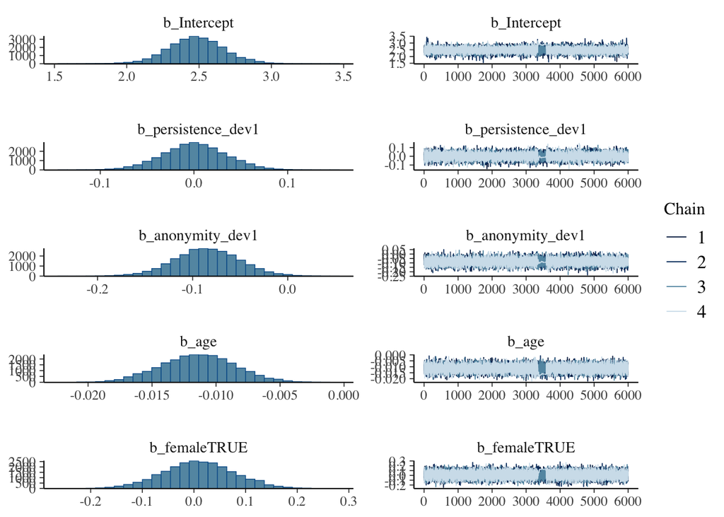

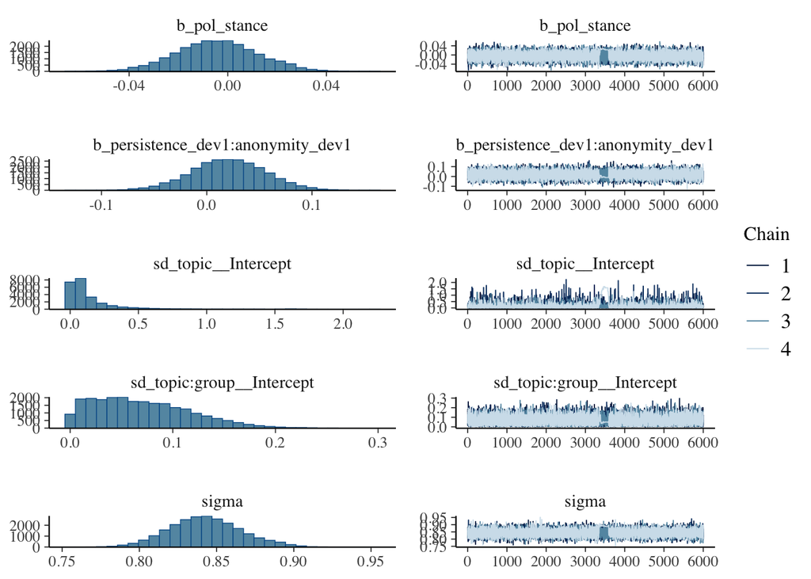

```r
plot(fit_fe_costs_1, ask = FALSE)
```

Traceplots look alright.

Let’s look at results.

```r
summary(fit_fe_costs_1)
```

```
 Family: gaussian
  Links: mu = identity; sigma = identity
Formula: costs ~ 1 + persistence_dev * anonymity_dev + age + female + pol_stance + (1 | topic/group)
   Data: d (Number of observations: 705)
  Draws: 4 chains, each with iter = 8000; warmup = 2000; thin = 1;
         total post-warmup draws = 24000

Multilevel Hyperparameters:
~topic (Number of levels: 3)
              Estimate Est.Error l-95% CI u-95% CI Rhat Bulk_ESS Tail_ESS
sd(Intercept)     0.14      0.21     0.00     0.72 1.00     1494      515

~topic:group (Number of levels: 48)
              Estimate Est.Error l-95% CI u-95% CI Rhat Bulk_ESS Tail_ESS
sd(Intercept)     0.07      0.05     0.00     0.17 1.00     6748     8434

Regression Coefficients:
                                Estimate Est.Error l-95% CI u-95% CI Rhat
Intercept                           2.48      0.19     2.10     2.87 1.00
persistence_dev1                    0.00      0.03    -0.07     0.07 1.00
anonymity_dev1                     -0.08      0.03    -0.15    -0.02 1.00
age                                -0.01      0.00    -0.02    -0.01 1.00
femaleTRUE                          0.01      0.07    -0.12     0.14 1.00
pol_stance                         -0.00      0.02    -0.04     0.03 1.00
persistence_dev1:anonymity_dev1     0.02      0.04    -0.05     0.09 1.00
                                Bulk_ESS Tail_ESS
Intercept                           2061      445
persistence_dev1                   23119    14791
anonymity_dev1                     22255    16736
age                                 3533     3184
femaleTRUE                          4726     1481
pol_stance                          4395     1896
persistence_dev1:anonymity_dev1    19628    14789

Further Distributional Parameters:
      Estimate Est.Error l-95% CI u-95% CI Rhat Bulk_ESS Tail_ESS
sigma     0.84      0.02     0.80     0.89 1.00     2480      483

Draws were sampled using sampling(NUTS). For each parameter, Bulk_ESS
and Tail_ESS are effective sample size measures, and Rhat is the potential
scale reduction factor on split chains (at convergence, Rhat = 1).
```

We find that anonymity does reduce costs.

## Mediation

Let’s see if perceived benefits and costs were associated with increased words communicated.

```r
fit_fe_med <-
  hush(
    brm(
      n_Words ~
        1 + persistence_dev * anonymity_dev + benefits + costs  + age + female + pol_stance +
        (1 | topic/group)
      , data = d
      , chains = 4
      , cores = 4
      , iter = 6000
      , warmup = 2000
      , family = zero_inflated_poisson()
      , control = list(
        adapt_delta = .95
        , max_treedepth = 12
        )
      )
  )
```

Let’s look at results.

```r
summary(fit_fe_med)
```

```
 Family: zero_inflated_poisson
  Links: mu = log; zi = identity
Formula: n_Words ~ 1 + persistence_dev * anonymity_dev + benefits + costs + age + female + pol_stance + (1 | topic/group)
   Data: d (Number of observations: 705)
  Draws: 4 chains, each with iter = 6000; warmup = 2000; thin = 1;
         total post-warmup draws = 16000

Multilevel Hyperparameters:
~topic (Number of levels: 3)
              Estimate Est.Error l-95% CI u-95% CI Rhat Bulk_ESS Tail_ESS
sd(Intercept)     0.19      0.22     0.00     0.80 1.00     2528     3504

~topic:group (Number of levels: 48)
              Estimate Est.Error l-95% CI u-95% CI Rhat Bulk_ESS Tail_ESS
sd(Intercept)     0.39      0.04     0.32     0.49 1.00     3616     5273

Regression Coefficients:
                                Estimate Est.Error l-95% CI u-95% CI Rhat
Intercept                           5.98      0.14     5.68     6.28 1.00
persistence_dev1                   -0.04      0.06    -0.16     0.07 1.00
anonymity_dev1                     -0.04      0.06    -0.15     0.07 1.00
benefits                            0.06      0.00     0.06     0.07 1.00
costs                              -0.14      0.00    -0.14    -0.14 1.00
age                                 0.01      0.00     0.01     0.01 1.00
femaleTRUE                         -0.09      0.00    -0.10    -0.09 1.00
pol_stance                         -0.01      0.00    -0.02    -0.01 1.00
persistence_dev1:anonymity_dev1     0.05      0.06    -0.06     0.16 1.00
                                Bulk_ESS Tail_ESS
Intercept                           4854     3306
persistence_dev1                    4193     5107
anonymity_dev1                      4213     5248
benefits                           12217     9176
costs                              12666     8803
age                                16687    12376
femaleTRUE                         12610     9014
pol_stance                         13892     8775
persistence_dev1:anonymity_dev1     4018     5166

Further Distributional Parameters:
   Estimate Est.Error l-95% CI u-95% CI Rhat Bulk_ESS Tail_ESS
zi     0.08      0.01     0.06     0.10 1.00    12135     7666

Draws were sampled using sampling(NUTS). For each parameter, Bulk_ESS
and Tail_ESS are effective sample size measures, and Rhat is the potential
scale reduction factor on split chains (at convergence, Rhat = 1).
```

We find that increased perceived costs are associated with decreased words communicated. Increased benefits are associated with increased words communicated. Let’s check if overall effect is significant.

```r
anon_costs_a_b <- fixef(fit_fe_costs_1)["anonymity_dev1", "Estimate"]
anon_costs_a_se <- fixef(fit_fe_costs_1)["anonymity_dev1", "Est.Error"]
anon_costs_a_dis <- rnorm(10000, anon_costs_a_b, anon_costs_a_se)

anon_costs_b_b <- fixef(fit_fe_med)["benefits", "Estimate"]
anon_costs_b_se <- fixef(fit_fe_med)["benefits", "Est.Error"]
anon_costs_b_dis <- rnorm(10000, anon_costs_b_b, anon_costs_b_se)

anon_costs_ab_dis <- anon_costs_a_dis * anon_costs_b_dis
anon_costs_ab_m <- median(anon_costs_ab_dis)
anon_costs_ab_ll <- quantile(anon_costs_ab_dis, .025)
anon_costs_ab_ul <- quantile(anon_costs_ab_dis, .975)
```

The effect is significant (*b* = -0.01, 95% MC CI [-0.01, 0]).

# Save

```r
save.image("data/image_words.RData")
```